# Table of Contents

As for oil-reliant households, we conservatively assume that they will not increase their consumption, given the higher price per unit of energy with the new system. However, we acknowledge that some households may choose to increase consumption due to the benefits of a more flexible and reliable energy source. With the ability to control their heating devices automatically, these households can enjoy a warmer house upon waking up or returning home from work, a convenience that was previously unavailable.

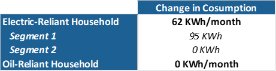

Our final note is that the marginal increase in wind energy consumption out of the currently curtailed energy will encompass the total energy used for heating and hot water by both the current oil-reliant and non-renewable electric-reliant households. Additionally, it will include only the additional consumption of energy by the current renewable electric-reliant households. Notably, households currently reliant on renewable energy sources will not tap into the curtailed energy bucket for their baseline consumption. This forms the foundation of the supplementary revenue generated from selling a portion of the currently curtailed wind energy.

**Cost of Goods Sold (COGS)**

**1. DR Hardware Cost**

There is a tangible cost associated with producing the DR devices, which includes material and hardware expenses. Typically, for a Software-as-a-Service company, the cost of goods sold (COGS) ranges from 10% to 20%, covering both hardware and software costs. We have assumed a 10% allocation for hardware costs per device, amounting to £10 (£100 Device Price $\times$ 10%).

**2. DR Device Installation Cost**

Each DR device is estimated to incur an installation cost of £90, which is included in Kaluza's sales fee but needs to be deducted as a cost since the amount will not contribute to Kaluza's profit and will be paid to a third party for the installation process.

**3. Discount on DR Devices**

To incentivise widespread adoption of Kaluza's DR devices and overcome the upfront investment barrier of £760 per household (£190 per device $\small{\times}$ 4 devices per household), we are offering a progressive discount program with a first-mover advantage. The first 1000 households to join will receive discounts ranging from 100% off for the initial 100 households, gradually decreasing in 25% increments for every subsequent 250 households until the 1000th household receives a 25% discount. Flexible financing options, such as interest-free payment plans or low-interest loans, will further alleviate the upfront cost burden. This incentive structure, combined with targeted marketing campaigns, partnerships with local community leaders, social media promotion, and a celebration of early adopters through testimonials and community events, aims to create a sense of urgency and exclusivity, thereby accelerating the adoption of DR technology and ensuring a critical mass of households participate in optimizing energy storage and utilization from the outset.

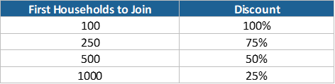

**4. Electric Appliances Subsidy for Oil-Reliant Households**

Furthermore, oil-reliant households will face a greater investment hurdle as they will need to not only purchase the DR devices but also replace their existing oil appliances with electric alternatives. For instance, a electric heater could be around £400 to £700, while a boiler could be around £800 to £1000. This segment of households may exhibit greater resistance to joining the program due to the compounded costs involved. To address this barrier, Kaluza should offer a subsidy to assist oil-reliant households in transitioning to electric appliances. This subsidy will be exclusively available to the first 100 oil-reliant households that join the program, providing them with additional financial support to cover the costs of replacing their oil-based heating systems and water heaters with electric counterparts compatible with the DR devices. By offering this targeted subsidy alongside the progressive discount on DR devices, Kaluza can alleviate the financial burden for early-adopting, oil-reliant households, encouraging their participation and accelerating the program's overall adoption rate.

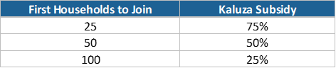

**5. Sales Bonus**

Finally, a crucial driver of revenue hinges on successfully selling the DR devices to households. To facilitate this, we have devised an aggressive sales strategy centred around a dedicated sales team. These sales representatives will be incentivized through an attractive bonus structure based on their monthly target achievement percentage. The bonus scheme will be structured progressively, with higher percentages of the target met resulting in increasingly lucrative pay-outs. For instance, achieving 80-100% of the monthly target could yield a £20 bonus per device sold. This performance-based incentive program aims to foster a highly motivated and driven sales force, empowering them to proactively engage with households, address concerns, and effectively communicate the value proposition of adopting Kaluza's DR devices. By combining an assertive sales approach with compelling financial incentives, we are confident in our ability to drive substantial DR device adoption and establish a strong revenue stream. We assumed that Kaluza already has a sales team, so we have not included their fixed annual salaries as part of the operational costs.

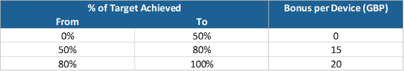

**Operational Costs**

**1. Marketing**

The marketing campaign will have a dual focus: raising awareness about the challenges of curtailed wind energy and the environmental impact of underutilizing renewable resources and relying on non-renewable sources, while also driving behaviour change towards adopting Kaluza's demand response (DR) technology and energy flexibility. Through educational initiatives and community outreach, we will shed light on the intermittent nature of wind power generation and the urgency of optimizing energy consumption during peak production periods. By quantifying the environmental benefits and potential cost savings, we aim to increase consciousness about the collective responsibility in transitioning towards a greener future. Marketing campaign will also focus on work with Wind Farmers because they are one of the most important stakeholders for the initiative, they will be able to gain extra profit from the energy that is not being curtailed anymore.

Simultaneously, the campaign will concentrate on motivating households to take action and embrace DR technology as a sustainable solution. We will address potential concerns, provide clear guidance on the retrofit process, and offer attractive incentives to encourage the initial behaviour change. By leveraging social proof, success stories, and a sense of community pride, we aim to inspire a widespread shift towards integrating Kaluza's DR devices into electric quantum heaters and water boilers. Ultimately, this comprehensive approach will empower households to become active participants in Orkney's renewable energy journey while enjoying the convenience of automated energy storage and utilization.

The marketing campaign will deploy in two phases, the first six months we will invest heavily in the actions stated above, assigning £50,000 per month, which will account for an investment of £300,000. During the next following 18 months, we will continue with smaller-scale marketing and engagement activities, where we will be investing £5,000 per month, to maintain the awareness and behavioural change we have achieved during the first six months of the program.

**2. Cloud Platform Costs**

The cloud platform cost encompasses the expenses associated with operating the cloud infrastructure responsible for managing and coordinating the home hubs. It facilitates communication between devices, adjusts operations based on real-time energy data, and ensures seamless integration. Costs are influenced by factors such as data processing, storage, network bandwidth, and security measures. As the number of connected devices increases, resource requirements increase, leading to higher operational costs across the following tiers.

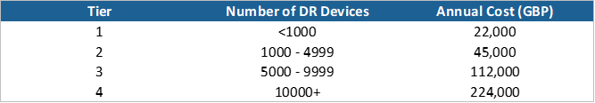

**Penetration Ratio Pattern**

Household adoption will progress gradually, plateauing by month 24. We anticipate different penetration rates for oil and electric-based households due to the additional investment required for oil-based homes to switch to electric appliances. Our projections assume an 80% maximum penetration for electric-based households, while oil-based households are expected to reach a 30% maximum penetration rate. Additionally, we anticipate no adopters in the first month as the awareness campaign will be freshly launched, allowing time for messaging to resonate with target audiences. Early adoption will be bolstered by incentives and subsidies, catalysing word-of-mouth and sustained growth until saturation is achieved at the projected thresholds for each household segment.

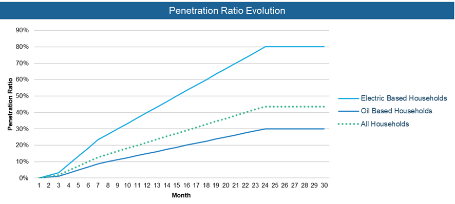

**Government Contribution**

While our projections do not currently account for any government subsidies for the DR devices or electric appliance conversion for oil-based households, we recognize the potential for governmental support to play a pivotal role in driving adoption. The government's involvement in spreading awareness about the initiative's importance and promoting the benefits of optimizing wind energy storage through DR technology could significantly amplify our marketing efforts.

Potential government incentives, such as rebates, tax credits, or low-interest financing options for purchasing DR devices and transitioning to electric appliances, could substantially lower the investment barrier for households. Further, subsidies towards wind energy prices, linked to CO2 emission reductions, could particularly benefit oil-reliant households, reducing the financial strain of transitioning to flexible electric-based heating systems. Such incentives would not only make the program more accessible to a broader audience but also signal the government's endorsement and alignment with the initiative's objectives.

Moreover, we anticipate the government could complement our awareness campaigns through public education initiatives, informational resources, and community outreach programs. This multi-faceted approach, combining our targeted marketing strategies with governmental awareness efforts and potential financial incentives, could accelerate adoption rates and enhance the overall impact of the initiative.

**Considerations Not Accounted For**

## Financial Evaluation: Should Kaluza pursue this project?

With the strategic plan and underlying assumptions in place, we now proceed to the critical step of evaluating the financial viability of this project. The detailed calculations of the financial model are included in Appendix 3. In this section, we present the simulated results of the financial model.

To begin, we examine the base scenario, incorporating the penetration rates of 80% for households reliant on electricity and 30% for those reliant on oil, resulting in a total penetration ratio of 44%. Subsequently, we explore various sensitivities to gauge how fluctuations in the penetration ratio affect the project's financial attractiveness.

The penetration rate, the proportion of households adopting Kaluza's demand response technology, is chosen as a reasonable variable for sensitivity analysis. It significantly influences market size, revenue projections, profitability, marketing effectiveness, competitive landscape, and risk assessment. Even minor changes in penetration rate assumptions can substantially impact market potential, future revenue streams, cash flows, and the overall robustness of the financial model under different market penetration scenarios.

### Run Base Penetration Ratio Scenario

The full results of the base scenario business case were saved in an excel file, *Final Base Scenario BC - Exported from Jupyter Notebook.xlsx*, which is included in the zipfolder.

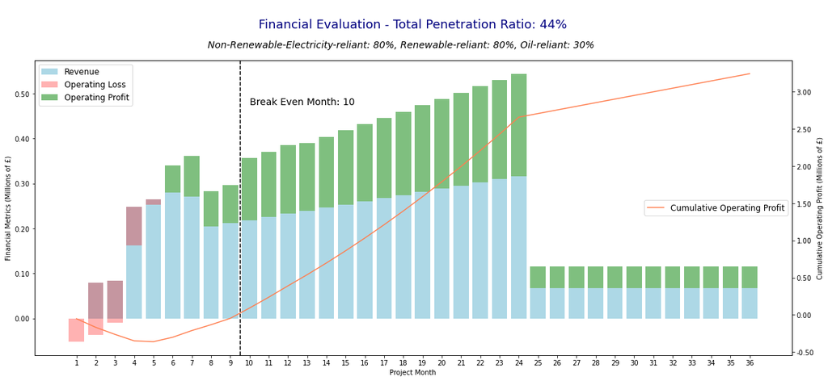

```python
results_base, breakeven_month_base, num_adopters_base, pen_ratios_base = results(0.8, 0.8, 0.3)
display_bc_results(results_base, breakeven_month_base, num_adopters_base, pen_ratios_base)
```

The penetration ratio, which represents the proportion of the target market adopting Kaluza's initiative, plays a crucial role in shaping the financial trajectory. The initial operating losses are attributable to the substantial upfront costs associated with launching the initiative and acquiring customers. However, as the penetration rate increases, driven by effective marketing efforts, the revenue stream from the growing customer base begins to outweigh the operating costs, resulting in operating profits.

### Run 70% Higher Penetration Ratio Scenario

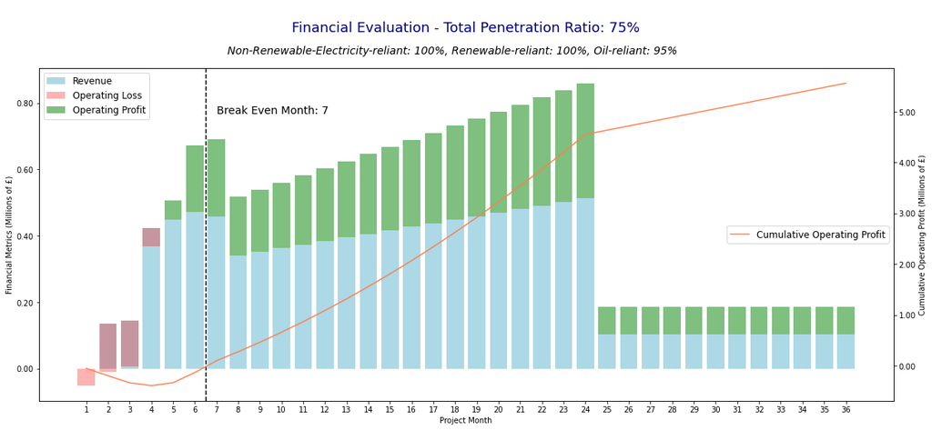

```python
results_70p_higher, breakeven_month_70p_higher, num_adopters_70p_higher, pen_ratios_70p_higher = results(1, 1, 0.95)
display_bc_results(results_70p_higher, breakeven_month_70p_higher, num_adopters_70p_higher, pen_ratios_70p_higher)
```

### Run 50% Higher Penetration Ratio Scenario

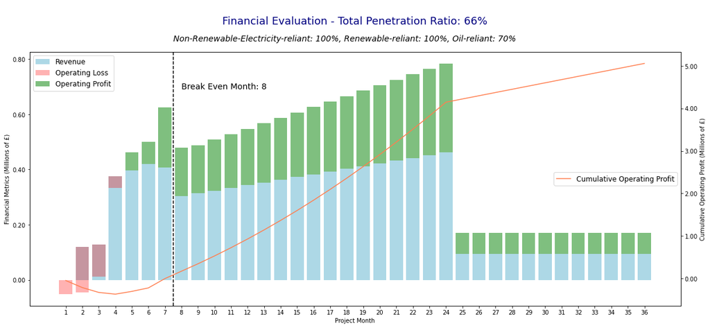

```python
results_50p_higher, breakeven_month_50p_higher, num_adopters_50p_higher, pen_ratios_50p_higher = results(1, 1, 0.7)
display_bc_results(results_50p_higher, breakeven_month_50p_higher, num_adopters_50p_higher, pen_ratios_50p_higher)
```

### Run 20% Higher Penetration Ratio Scenario

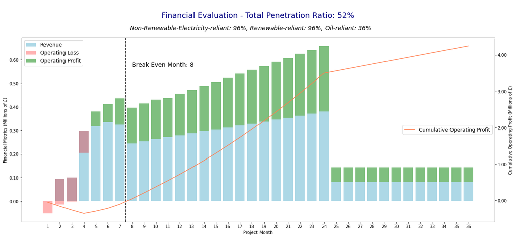

```python
results_20p_higher, breakeven_month_20p_higher, num_adopters_20p_higher, pen_ratios_20p_higher = results(0.96, 0.96, 0.36)
display_bc_results(results_20p_higher, breakeven_month_20p_higher, num_adopters_20p_higher, pen_ratios_20p_higher)
```

### Run 20% Lower Penetration Ratio Scenario

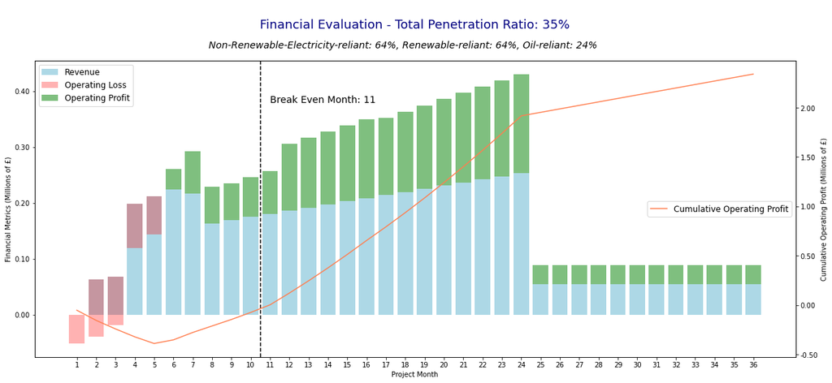

```python
results_20p_lower, breakeven_month_20p_lower, num_adopters_20p_lower, pen_ratios_20p_lower = results(0.64, 0.64, 0.24)
display_bc_results(results_20p_lower, breakeven_month_20p_lower, num_adopters_20p_lower, pen_ratios_20p_lower)
```

### Run 50% Lower Penetration Ratio Scenario

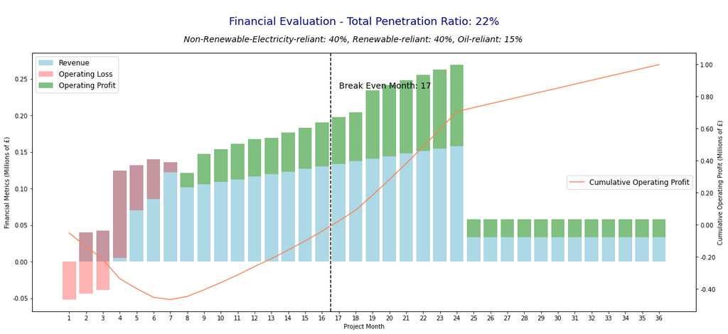

```python
results_50p_lower, breakeven_month_50p_lower, num_adopters_50p_lower, pen_ratios_50p_lower = results(0.4, 0.4, 0.15)
display_bc_results(results_50p_lower, breakeven_month_50p_lower, num_adopters_50p_lower, pen_ratios_50p_lower)
```

### Run 70% Lower Penetration Ratio Scenario

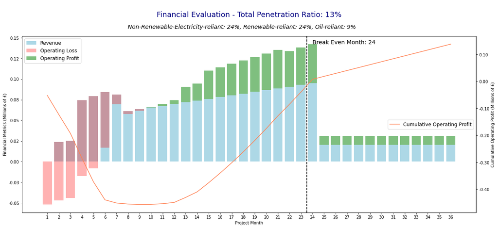

```python
results_70p_lower, breakeven_month_70p_lower, num_adopters_70p_lower, pen_ratios_70p_lower = results(0.24, 0.24, 0.09)
display_bc_results(results_70p_lower, breakeven_month_70p_lower, num_adopters_70p_lower, pen_ratios_70p_lower)
```

Within the crafted scenarios lies the blueprint for financial success! In our base scenario, Kaluza strides confidently towards the breakeven point by month 10, achieving a cumulative revenue of nearly £5.8 million and a cumulative operating profit of £2.66 million by the end of the two years of active operations; not to mention the run off of passive revenue and profit to follow generated from the wind farmers fee paid to Kaluza for each unit of curtailed energy that is now being utilised. Fueling these results is the assumption of a 44% penetration ratio across Orkney Islands, with 4,700 households adopting Kaluza's demand response technology. However, as the pendulum of penetration swings, the allure of the project ebbs and flows. Below are the details:

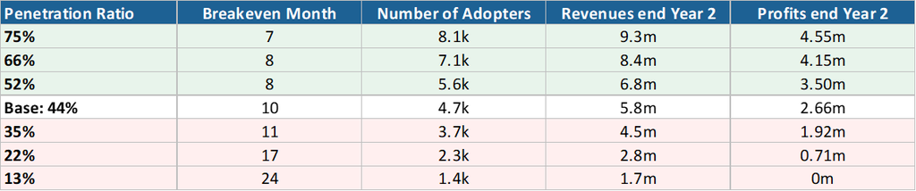

Setting our sights on a crucial tipping point: the 15% penetration ratio. Once crossed, the project's financial appeal diminishes, indicating a suboptimal scenario. At the 25% threshold, we establish a bottom line, insisting on a minimum profit of £1 million by project culmination to justify continued pursuit of this project. However, with faith in Kaluza's capabilities and the community's aspiration towards a cleaner, more sustainable energy landscape, we confidently assert that surpassing the 25% milestone is well within our reach. Therefore, we advocate embarking on this transformative journey, where innovation intertwines with sustainability to yield profitability.

## Beyond Kaluza - Empowering the Community

At the core of Kaluza's mission lies the commitment to accelerate a sustainable, affordable, and resilient energy transition. Central to this ethos is ensuring that every project undertaken by Kaluza delivers tangible benefits to the community. Our business model exemplifies this dedication, as it not only enriches Kaluza but also empowers the entire community toward a greener, more affordable, and sustainable future.

**Households:**

Beginning with the households, our initiative offers flexible, affordable clean energy solutions that often outmatch the prices of their current heating sources. By providing access to this renewable energy, households can now experience warmer homes with lower financial strain of high heating costs.

**Environmental Impact:**  
Every megawatt-hour of clean wind energy replaces a non-renewable heating source, prevalent in Orkney. This transition results in avoiding approximately 0.06 tonnes of CO2 emissions per megawatt-hour. In the base scenario, after the project's full implementation from year 3 onwards, we anticipate **curbing 2000 tonnes of CO2 emissions annually**. Here, curtailment takes on a positive connotation, signifying a significant step towards environmental sustainability.

### Base Scenario - Wind Farmers Benefit

```python
results_base_wind = pd.DataFrame({'curtailed_wind_sold_MWh': results_base['curtailed_wind_sold']/1e3,
                                 'wind_farmer_revenues_mil': results_base['wind_farmer_revenue']/1e6,
                                 'year': np.array(range(horizon)) // 12+1})

results_base_wind = results_base_wind.groupby('year').sum().round(2)

results_base_wind
```

| year | curtailed_wind_sold_MWh | wind_farmer_revenues_mil |
| --- | --- | --- |
| 1 | 7692.31 | 0.45 |
| 2 | 24222.58 | 1.56 |
| 3 | 31423.88 | 3.23 |

### Worst Scenario - Wind Farmers Benefit

```python
results_worst_wind = pd.DataFrame({'curtailed_wind_sold_MWh': results_70p_lower['curtailed_wind_sold']/1e3,
                                 'wind_farmer_revenues_mil': results_70p_lower['wind_farmer_revenue']/1e6,
                                 'year': np.array(range(horizon)) // 12+1})

results_worst_wind = results_worst_wind.groupby('year').sum().round(2)

results_worst_wind
```

| year | curtailed_wind_sold_MWh | wind_farmer_revenues_mil |
| --- | --- | --- |
| 1 | 2307.69 | 0.13 |
| 2 | 7266.77 | 0.47 |
| 3 | 9427.17 | 0.97 |

### Best Scenario - Wind Farmers Benefit

```python
results_best_wind = pd.DataFrame({'curtailed_wind_sold_MWh': results_70p_higher['curtailed_wind_sold']/1e3,
                                 'wind_farmer_revenues_mil': results_70p_higher['wind_farmer_revenue']/1e6,
                                 'year': np.array(range(horizon)) // 12+1})

results_best_wind = results_best_wind.groupby('year').sum().round(2)

results_best_wind
```

| year | curtailed_wind_sold_MWh | wind_farmer_revenues_mil |
| --- | --- | --- |
| 1 | 13715.11 | 0.68 |
| 2 | 43188.00 | 2.38 |
| 3 | 56027.67 | 4.93 |

# Conclusion

In this report, we embarked on a journey to quantify the annual wind energy curtailment in the Orkney Islands, located in the north of Scotland, where despite an abundance of renewable energy, fuel poverty remains a significant issue. Our analysis revealed an estimated annual curtailed energy of 70.7 GWh, representing approximately 40% of the islands' potential wind energy generation. This was done by leveraging sample turbine data from Rousay Islands and residential demand data from 2017, supplemented we employed informed interpolations and approximations to gain comprehensive insights into the islands' energy dynamics.

Through our data analysis, we identified a mismatch between wind energy supply and residential demand patterns, particularly in peak and off-peak hours, which validates with our initial hypothesis. Consequently, we proposed Kaluza's demand-response system (DR), integrated with heating appliances representing the highest portion of household energy usage, as an ideal solution to synchronize residential demand with supply without necessitating costly grid infrastructure changes.

We crafted a roadmap to revolutionise the heating landscape in the Orkney Islands, led by Kaluza and reinforced by community support, benefitting all stakeholders involved. The 24-month transformation project commences with strong marketing, campaigning, and community engagement, targeting households, wind farmers, and local council and government representatives. Through these efforts, including discounted wind energy prices, DR device subsidies, subsidies for transitioning to electric heating appliances, coupled with a dedicated and incentivized sales team from Kaluza, we anticipate gradual increasing household adoption of the DR system. This adoption promises a cascade of benefits, including revenue for wind farmers, profits for Kaluza, reduced carbon emissions aligning with green targets, and improved heating practices offering affordable, clean, and flexible solutions for households.

The transformation demonstrates benefits across various penetration ratios, as illustrated in the following table. We firmly believe that achieving a penetration ratio of at least 25% is not only feasible but also an easily attainable target, particularly given that 31% of the community relies on non-renewable electric heating appliances, where transitioning to wind energy and adopting the DR system would yield cost savings.

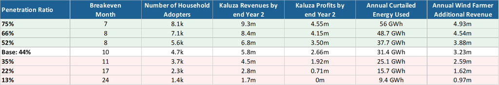

In the subsequent section, we address the limitations of our study and results.

# Limitations

This section outlines the limitations on the study, emanating from limited data, key assumptions that may be invalidated and challenges due to technology and policy changes. Curtailment Estimation and Business Solution Formulation and Quantification. Notably, considerations not factored into the financial evaluation of the solution are exhaustively addressed in their respective section here and will not be reiterated in this section.

### **Curtailment Estimation**

**Data Discrepancies:**

Although the turbine telemetry and residential demand datasets provided valuable insights, they were affected by inaccuracies and missing information. Consequently, some figures derived from these datasets may compromise confidence and integrity to some extent. Nevertheless, our approach to data treatment prioritized minimal intervention, restricted interpolations, and avoided artificial data synthesis or non-scientific assumptions.

**Turbines Performance:**

A key challenge in predicting curtailment is the fact that we have data for only one turbine for a limited period that we use to extrapolate the total turbines generation capacity from. This turbine has a design capacity of 900kW, which is typical of most commercial turbines in Orkney, but there are a number of different sizes, from smaller domestic ones to the 2.75MW at Burgar Hill. These turbines will have different characteristics and their performance may also be affected by different locations and turbine lifetime. Nonetheless, our modelling approach serves as a framework to extend the model to all turbines if individual turbine data becomes accessible.

**Total Demand:**

Solely relying on residential demand data may not offer a comprehensive view of energy demand in Orkney. While obtaining total demand figures from published sources by Orkney Islands council seemed plausible, it would have misrepresented the actual demand, as these figures encompass all energy sources. Hence, we opted to scale up residential demand by an arbitrary factor to approximate non-domestic demand relying on renewable energy. Despite the reliance on this factor, the core conclusion remains unchanged: there exists a significant curtailment issue for wind energy in Orkney, regardless of the precise percentage estimated.

### **Business Solution Formulation & Quantification**

**Grid Connections and Turbine Capacity Expansion:**

Although we assume that every wind turbine on the island is connected to the grid, one key factor in curtailment and the ban on new connections since 2012 is the limitation due to the lack of grid capacity and the 40MW cable connecting to the mainland. There is an existing project by Scottish and Southern Electricity Networks to enhance the power network within Orkney and lay a 220MW capacity cable to the Scottish mainland. Conditional approval has been obtained from Ofgem subject to an additional 135MW of generating capacity coming online in due course. A number of projects are under consideration to expand capacity at different locations. Other projects under consideration are looking into possibilities of converting surplus electricity into hydrogen and other means of energy storage.

Whilst these projects, particularly the cable connection expansion, may seem to alleviate curtailment in the short term, thereby reducing the available "curtailed energy" for our proposed solution, the favourable island location and governmental encouragement for renewable energy expansion suggest continued investment interest, leading to a persistence of curtailment issues. Demand management is an issue in grid performance in general. The switch to heat pumps and adoption of electric vehicles is already causing major problems in grid capacity in a number of areas in the UK and demand management is a low cost option to relieve grid capacity.

**The net-zero challenge and technology changes:**

The use of surplus electrical energy will definitely be a welcomed contribution to lowering carbon emissions. As such in our analysis we have assumed that conversions would be from fossil fuel heating to storage heaters. However, the government is actively encouraging a switch to heat pumps, as a more efficient option. New gas fired boilers are to be banned in new builds and consumers are subsidised by significant amounts to replace boilers with heat pumps. The advantage of a heat pump compared to electric storage heaters is that the heat pump in effect transfers energy from the external environment into the house, resulting in an effective efficiency of 300%, compared to electric storage heaters or kerosene and gas boilers that are below 100%. This makes heat pumps competitive with gas or kerosene at current electricity charges, whilst storage heaters can only compete using off-peak rates at a substantially lower cost. However, heat pumps do not provide the storage capability of storage heaters enabling demand management and cannot utilise off-peak rates as they have no storage capability. Furthermore, the installation cost is prohibitively high, but is reduced to competitive levels due to the government subsidy. Nevertheless, the only way that heat pumps can help manage curtailment is by the addition of battery storage, which will have an additional cost of about £5000 per household for 10kWh, thus partially offsetting the benefits.

**Costs Quantification:**

Our quantification of costs included an analysis of the performance of storage heating appliances and the determination of the number of devices required per household, relying on performance metrics provided directly by manufacturers. While actual testing in houses may reveal variations in performance and energy demand, we anticipate minimal differences.

Furthermore, the estimation of costs for goods sold and operational expenses was heavily reliant on assumptions and market benchmarks. However, we are confident that these estimates fall within a reasonable range. It is important to note that this business case serves as a foundational step in determining whether Kaluza should pursue this opportunity. Typically, this stage is followed by a detailed analysis by a project management team, which delves into specific cost items to refine estimates and replace them with actual costs while ensuring alignment with the overall project budget.

**Other Devices and Appliances:**

While our analysis primarily focused on heating appliances as an opportunity for utilizing curtailed energy, it's important to note the potential impact of electric and hybrid vehicles. These vehicles are poised for widespread adoption and promotion, especially in forward-thinking regions like the Orkney Islands. Electric vehicles not only offer the potential to utilize renewable wind energy but also serve as battery storage units themselves. Through a process known as "Vehicle-To-Home", charged energy can be used to partially power homes, even when it's not being utilized for transportation purposes. Additionally, integrating their charging mechanism into a smart charging infrastructure, possibly engineered by Kaluza, would enable the synchronization of demand with supply by triggering vehicle charging during periods of high wind power generation.

We have outlined the primary limitations of our analysis and findings. However, despite these challenges, we stand by the value of the proposed solution and view it as a compelling opportunity for Kaluza to pursue. Beyond the potential financial gains, this project offers invaluable experience and networking opportunities, providing a solid foundation for future expansions and impactful initiatives.

# References

1. Sub-national Electricity and Gas Consumption Summary Report 2018. Available at: https://assets.publishing.service.gov.uk/media/5dfa803aed915d54ab87c860/sub-national-electricity-and-gas-consumption-summary-report-2018.pdf
2. Physics of Wind Turbines. University of Leipzig. Available at: https://home.uni-leipzig.de/energy/energy-fundamentals/15.htm#:~:text=The%20wind%20power%20increases%20with,important%20for%20a%20wind%20turbine
3. Wind Power. Energy Education. Available at: https://energyeducation.ca/encyclopedia/Wind_power
4. Analysis of the influence of the wind speed profile on wind power production. Available at: https://www.sciencedirect.com/science/article/pii/S2352484722011854#fig2
5. Orkney’s Fuel Poverty Strategy 2017-2022. Available at: https://www.orkney.gov.uk/Files/Housing/Housing%20Options/Housing%20Strategy/Fuel_Poverty_Strategy.pdf
6. Orkney Renewable Energy Forum (OREF). Available at: https://www.oref.co.uk/orkneys-energy-1/wind/Waters
7. Orkney Energy Audit 2014. Available at: https://www.oref.co.uk/wp-content/uploads/2015/05/Orkney-wide-energy-audit-2014-Energy-Sources-and-Uses.pdf
8. Orkney Energy Audit 2019. Available at: https://www.oref.co.uk/wp-content/uploads/2023/04/ReFLEX-Orkney-Energy-Audit-2019-V3.pdf
9. National Grid ESO Future Energy Strategy. Available at: https://www.nationalgrideso.com/future-energy
10. Scotland Census Data. Available at: https://www.scotlandscensus.gov.uk
11. Kaluza Demand Response. Available at: https://www.kaluza.com/demand-response/
12. Orkney Renewable Overview. Available at: https://www.orkney.com/life/energy/renewables
13. National Records of Scotland Household Report. Available at: https://www.nrscotland.gov.uk/files//statistics/household-projections/18/household-proj-18-report.pdf
14. Hot Water Cylinder Calculator. Available at: https://www.hotwater.org.uk/hot-water-cylinder-calculator/
15. Dimplex Product Catalogue. Available at: https://www.dimplex.co.uk/sites/default/files/Dimplex%20product%20catalogue.pdf
16. UK Quarterly Energy Prices. Available at: https://assets.publishing.service.gov.uk/media/5c9b80f040f0b633fd3b0c11/QEP_Q4_2018.pdf
17. HSO Smart Orkney Trial Project Report. Available at: https://communityenergyscotland.org.uk/wp-content/uploads/2023/02/HSO-report-Final-Version-for-LECF-Nov-2020.pdf

We import essential libraries for data manipulation, analysis, and visualization, and then load the Turbine_telemetry.csv and Residential_demand.csv datasets, parsing dates for proper time-series analysis.

```python
#data wrangling packages
import pandas as pd
import numpy as np
from scipy.interpolate import interp1d

#plotting packages
import matplotlib.pyplot as plt
import seaborn as sns
import plotly.express as px
from matplotlib.dates import DateFormatter
from matplotlib.patches import ConnectionPatch
import matplotlib.ticker as ticker

#Curve Fit package
from scipy.optimize import curve_fit
```

```python
turbine_telemetry = pd.read_csv("Turbine_telemetry.csv", parse_dates=[0])
residential_demand = pd.read_csv("Residential_demand.csv", parse_dates=[0])
```

# Appendix

## Appendix 1: Turbine Telemetry Data Pre-Processing

The data includes a timestamp at a second granularity, the average amount of power generated during the time interval (measured in kilowatts), the set point representing the mean-maximum possible generator output during the time interval (measured in kilowatts), and the mean wind speed during the time interval (measured in meters per second).

```python
turbine_telemetry.head(10)
```

|  | Timestamp | Power_kw | Setpoint_kw | Wind_ms |
| --- | --- | --- | --- | --- |
| 0 | 2015-05-28 00:00:23 | 80.0 | 900.0 | 4.9 |
| 1 | 2015-05-28 00:01:23 | 78.0 | 900.0 | 5.4 |
| 2 | 2015-05-28 00:02:23 | 52.0 | 900.0 | 4.9 |
| 3 | 2015-05-28 00:03:23 | 57.0 | 900.0 | 4.6 |
| 4 | 2015-05-28 00:04:23 | 54.0 | 900.0 | 4.6 |
| 5 | 2015-05-28 00:05:23 | 44.0 | 900.0 | 4.5 |
| 6 | 2015-05-28 00:06:23 | 62.0 | 900.0 | 4.5 |
| 7 | 2015-05-28 00:07:23 | 51.0 | 900.0 | 4.1 |
| 8 | 2015-05-28 00:08:23 | 155.0 | 900.0 | 6.4 |
| 9 | 2015-05-28 00:09:23 | 90.0 | 900.0 | 5.2 |

Upon initial observation, it appears that the readings are captured at the end of 1-minute intervals. However, this hypothesis will require validation.

*Inspect Data Types*

```python
turbine_telemetry.dtypes #all columns are the right data types
```

```
Timestamp      datetime64[ns]
Power_kw              float64
Setpoint_kw           float64
Wind_ms               float64
dtype: object
```

*Summary Statistics of Data*

```python
turbine_telemetry.describe().round(2)
```

|  | Power_kw | Setpoint_kw | Wind_ms |
| --- | --- | --- | --- |
| count | 1066934.00 | 1066921.00 | 1066931.00 |
| mean | 367.19 | 810.66 | 9.96 |
| std | 339.96 | 261.51 | 5.45 |
| min | 0.00 | 0.00 | 0.00 |
| 25% | 51.00 | 900.00 | 6.10 |
| 50% | 251.00 | 900.00 | 9.00 |
| 75% | 704.00 | 900.00 | 12.40 |
| max | 938.00 | 900.00 | 47.20 |

*Check for Missing Values in existing entries*

```python
# Count missing entries per column
missing_count = turbine_telemetry.isnull().sum()

# Display count of missing entries per column
print("\nMissing Entries per Column:")
print(missing_count)
```

```
Missing Entries per Column:
Timestamp         0
Power_kw       2702
Setpoint_kw    2715
Wind_ms        2705
dtype: int64
```

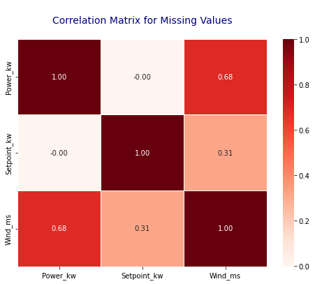

```python
# Create a correlation matrix for missing values
missing_corr = turbine_telemetry.drop(columns = ['Timestamp']).isnull().corr()
fig, ax = plt.subplots(figsize=(8, 6))
sns.heatmap(missing_corr, annot=True, cmap='Reds', fmt='.2f', linewidths=0.5, ax=ax)
ax.set_title('\nCorrelation Matrix for Missing Values\n', size=14, color="navy")
corr_matrix_tt = fig
```

There is a relatively high correlation between wind speed being missing and the power measurement being missing potentially indicating that the was an error in the telemetry at the sepecific time intervals.

```python
# Display % of entries with missing values
print("\nPercentage of Entries with missing values:",
      round(turbine_telemetry.isnull().any(axis=1).sum()/len(turbine_telemetry)*100,3), "%")
```

```
Percentage of Entries with missing values: 0.506 %
```

Since the percentage of entries with missing values is not material (0.51%), these entries will be excluded from the database.

```python
turbine_telemetry=turbine_telemetry.dropna()
```

*Check Time Interval Hypothesis and Treat Missing Readings*

```python
# Calculate frequency of each time difference
time_diff_counts = turbine_telemetry['Timestamp'].diff().value_counts()
total_count = time_diff_counts.sum()

# Create a DataFrame to represent the frequency table
frequency_table = pd.DataFrame({'Time Difference': time_diff_counts.index, 'Frequency': time_diff_counts.values})
frequency_table['Percentage'] = (frequency_table['Frequency'] / total_count) * 100


print("\nFrequency Table of Time Differences:\n")
print(frequency_table)
```

```
Frequency Table of Time Differences:

    Time Difference  Frequency  Percentage
0   0 days 00:01:00    1049127   98.581963
1   0 days 00:01:01       4305    0.404522
2   0 days 00:00:59       4181    0.392871
3   0 days 00:02:00       2168    0.203718
4   0 days 00:00:04       1124    0.105617
..              ...        ...         ...
146 0 days 00:15:01          1    0.000094
147 0 days 00:14:59          1    0.000094
148 0 days 00:00:37          1    0.000094
149 0 days 00:00:23          1    0.000094
150 0 days 01:08:00          1    0.000094

[151 rows x 3 columns]
```

```python
print("The minimum time interval: ", min(frequency_table['Time Difference']))
print("The maximum time interval: ", max(frequency_table['Time Difference']))
```

```
The minimum time interval:  0 days 00:00:01
The maximum time interval:  98 days 00:01:07
```

Examining the time differences reveals variations in the measurement intervals. The analysis indicates that a large majority (98.5%) of the measurements have a one-minute interval, aligning well with the initial assumption and providing a high level of confidence. Additionally, approximately 0.8% of the entries deviate by one second from the one-minute gap, which falls within an acceptable range to maintain the one-minute interval criterion, albeit posing a challenge when identifying missing or duplicate intermediate readings. Further investigation is needed for the remaining time differences. Initially, we will examine the timestamp histogram to identify the days-long gaps which we have observed in the maximum time interval.

```python
def plot_monthly_frequency(monthly_counts):
    """
    Plot the bar chart for the frequency of readings per month.

    Parameters:
    - monthly_counts: Pandas Series containing the monthly counts of readings.

    Returns:
    None
    """
    fig=plt.figure(figsize=(15, 5))
    monthly_counts.plot(kind='bar', color='skyblue', edgecolor='black', width=1)
    plt.title('\nFrequency of Readings per Month\n', size=15, color='navy')
    plt.xlabel('Month')
    plt.ylabel('Frequency')
    plt.xticks(rotation=45)
    plt.tight_layout()
    plt.show()
    return fig
```

```python
# Get the minimum and maximum dates from the Timestamp column
min_date = turbine_telemetry['Timestamp'].min().date()
max_date = turbine_telemetry['Timestamp'].max().date()

# Create a range of all months between the minimum and maximum dates
all_months = pd.date_range(start=min_date, end=max_date, freq='MS').to_period('M')


# Count the number of entries for each month
monthly_counts = turbine_telemetry['Timestamp'].dt.to_period('M').value_counts().reindex(all_months, fill_value=0)
```

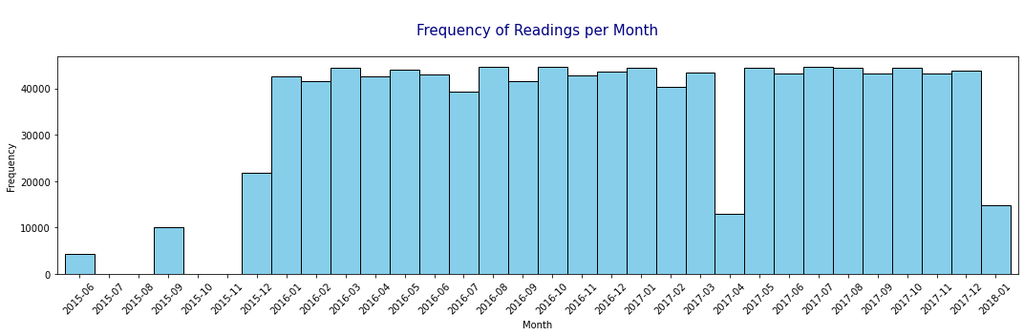

```python
plot1_readingsfrequency=plot_monthly_frequency(monthly_counts)
```

```python
print("Expected average number of readings per month if all readings exist: ", int(60*24*30.47), "readings.")
```

```
Expected average number of readings per month if all readings exist:  43876 readings.
```

Regarding the data prior to January 2016, it can be inferred that this period represents a testing phase of the turbine or the telemetry, during which it may not have been operating at full capacity. Therefore, these entries will be filtered out.

Regarding the January 2018 data, this too will be discarded as it is suspected to not add much value to the analysis given its incompleteness.

As for the incomplete data for April 2017, further investigation and decision-making are required to determine the appropriate approach for handling these missing readings. In the next section, we will look into identifying the missing readings. Additionally, we will test if the are any duplicate readings, although there is no striking indication of that.

```python
# Exclude data prior to January 2016
turbine_telemetry = turbine_telemetry[(turbine_telemetry['Timestamp'] >= '2016-01-01 00:00:00') &
                                      (turbine_telemetry['Timestamp'] < '2018-01-01 00:00:00')]
```

```python
# Sense Check by displaying first entries of the filtered turbine telemetry dataframe
turbine_telemetry.head(10)
```

|  | Timestamp | Power_kw | Setpoint_kw | Wind_ms |
| --- | --- | --- | --- | --- |
| 42051 | 2016-01-01 00:00:34 | 904.0 | 900.0 | 17.0 |
| 42052 | 2016-01-01 00:01:34 | 899.0 | 900.0 | 15.1 |
| 42053 | 2016-01-01 00:02:34 | 911.0 | 900.0 | 18.1 |
| 42054 | 2016-01-01 00:03:34 | 900.0 | 900.0 | 23.1 |
| 42055 | 2016-01-01 00:04:34 | 903.0 | 900.0 | 19.4 |
| 42056 | 2016-01-01 00:05:34 | 892.0 | 900.0 | 15.1 |
| 42057 | 2016-01-01 00:06:34 | 894.0 | 900.0 | 14.2 |
| 42058 | 2016-01-01 00:07:34 | 894.0 | 900.0 | 12.4 |
| 42059 | 2016-01-01 00:08:34 | 899.0 | 900.0 | 13.0 |
| 42060 | 2016-01-01 00:09:34 | 849.0 | 900.0 | 13.1 |

```python
# Sense Check by displaying last entries of the filtered turbine telemetry dataframe
turbine_telemetry.tail(10)
```

|  | Timestamp | Power_kw | Setpoint_kw | Wind_ms |
| --- | --- | --- | --- | --- |
| 1054870 | 2017-12-31 23:50:32 | 55.0 | 900.0 | 4.8 |
| 1054871 | 2017-12-31 23:51:32 | 46.0 | 900.0 | 4.8 |
| 1054872 | 2017-12-31 23:52:32 | 58.0 | 900.0 | 5.0 |
| 1054873 | 2017-12-31 23:53:32 | 52.0 | 900.0 | 4.9 |
| 1054874 | 2017-12-31 23:54:32 | 63.0 | 900.0 | 5.1 |
| 1054875 | 2017-12-31 23:55:32 | 53.0 | 900.0 | 4.9 |
| 1054876 | 2017-12-31 23:56:32 | 54.0 | 900.0 | 5.0 |
| 1054877 | 2017-12-31 23:57:32 | 67.0 | 900.0 | 5.1 |
| 1054878 | 2017-12-31 23:58:32 | 63.0 | 900.0 | 5.6 |
| 1054879 | 2017-12-31 23:59:32 | 74.0 | 900.0 | 5.4 |

An interesting observation is apparent here: while the time intervals appear to be consistently one minute apart, they are no longer consistently taken at the 23rd second, as observed in the initial entries of the database before applying the date filter. In this instance, they appear to be taken at the 34th second. This explains the discrepancies that were seen in the time differences between the consecutive readings.

```python
# Check for duplicate timestamps
duplicate_timestamps = turbine_telemetry[turbine_telemetry.index.duplicated(keep='first')]

# Print duplicate timestamps
print("Duplicate timestamps:")
print(duplicate_timestamps)
```

```
Duplicate timestamps:
Empty DataFrame
Columns: [Timestamp, Power_kw, Setpoint_kw, Wind_ms]
Index: []
```

This confirms that there are no duplicated/repeated readings.

Now, prior to addressing missing values, we will resample the data by averaging all readings within one-minute intervals and associating them with the start of each minute (second 0), instead of varying intermediate seconds points. This adjustment ensures consistency across minute intervals despite variations in the exact second of reading within each minute.

```python
# Resample and calculate the mean for each 30-second interval
turbine_telemetry_resampled = turbine_telemetry.set_index('Timestamp').resample('60S').mean().reset_index()

# Display the resampled DataFrame
turbine_telemetry_resampled.head(10)
```

|  | Timestamp | Power_kw | Setpoint_kw | Wind_ms |
| --- | --- | --- | --- | --- |
| 0 | 2016-01-01 00:00:00 | 904.0 | 900.0 | 17.0 |
| 1 | 2016-01-01 00:01:00 | 899.0 | 900.0 | 15.1 |
| 2 | 2016-01-01 00:02:00 | 911.0 | 900.0 | 18.1 |
| 3 | 2016-01-01 00:03:00 | 900.0 | 900.0 | 23.1 |
| 4 | 2016-01-01 00:04:00 | 903.0 | 900.0 | 19.4 |
| 5 | 2016-01-01 00:05:00 | 892.0 | 900.0 | 15.1 |
| 6 | 2016-01-01 00:06:00 | 894.0 | 900.0 | 14.2 |
| 7 | 2016-01-01 00:07:00 | 894.0 | 900.0 | 12.4 |
| 8 | 2016-01-01 00:08:00 | 899.0 | 900.0 | 13.0 |
| 9 | 2016-01-01 00:09:00 | 849.0 | 900.0 | 13.1 |

```python
# Validate the resampling step by comparing the summary statistics of the oringinal dataframe and re-sampled dataframe

telemetry_stats = turbine_telemetry.describe()

resampled_stats = turbine_telemetry_resampled.describe()

# Concatenate summary statistics side by side
summary_comparison = pd.concat([telemetry_stats, resampled_stats], axis=1,
                               keys=('Original Telemetry Stats', 'Resampled Telemetry Stats')).astype(int)


summary_comparison
```

|  | Original Telemetry Stats Power_kw | Original Telemetry Stats Setpoint_kw | Original Telemetry Stats Wind_ms | Resampled Telemetry Stats Power_kw | Resampled Telemetry Stats Setpoint_kw | Resampled Telemetry Stats Wind_ms |
| --- | --- | --- | --- | --- | --- | --- |
| count | 1007421 | 1007421 | 1007421 | 1004943 | 1004943 | 1004943 |
| mean | 361 | 807 | 9 | 361 | 808 | 9 |
| std | 338 | 264 | 5 | 338 | 264 | 5 |
| min | 0 | 0 | 0 | 0 | 0 | 0 |
| 25% | 48 | 900 | 6 | 48 | 900 | 6 |
| 50% | 244 | 900 | 8 | 244 | 900 | 8 |
| 75% | 687 | 900 | 12 | 687 | 900 | 12 |
| max | 938 | 900 | 47 | 938 | 900 | 47 |

```python
# Generate a complete time range
complete_time_range = pd.date_range(start=turbine_telemetry_resampled['Timestamp'].min(),
                                    end=turbine_telemetry_resampled['Timestamp'].max(), freq='T')
```

```python
# Create a DataFrame with the complete time range
complete_df = pd.DataFrame({'Timestamp': complete_time_range})

# Merge the original data with the complete time range data to identify missing values
complete_tt_resampled = complete_df.merge(turbine_telemetry_resampled, on='Timestamp', how='left')

# Check for missing values
missing_values = complete_tt_resampled[complete_tt_resampled.isnull().any(axis=1)]

# Print count of missing values
print("\nCount of Missing Readings:", missing_values.shape[0],
      f"readings, representing { round(missing_values.shape[0]/ complete_tt_resampled.shape[0],4)}%.")
# missing_values['Timestamp']
```

```
Count of Missing Readings: 47697 readings, representing 0.0453%.
```

```python
# Convert the list to a DataFrame
missing_df = pd.DataFrame({'Timestamp': missing_values['Timestamp']})

# Extract month and year information
missing_df['MonthYear'] = missing_df['Timestamp'].dt.to_period('M')

# Count the number of timestamps for each month/year
count_per_month_year =  missing_df.groupby('MonthYear').size()


count_per_month_year
```

```
MonthYear
2016-01     2015
2016-02      308
2016-03      180
2016-04      531
2016-05      620
2016-06      235
2016-07     5580
2016-08       79
2016-09     1657
2016-10      280
2016-11      376
2016-12     1522
2017-01      295
2017-02      118
2017-03     1179
2017-04    30200
2017-05      653
2017-06      205
2017-07      160
2017-08      134
2017-09      136
2017-10      264
2017-11      242
2017-12      728
Freq: M, dtype: int64
```

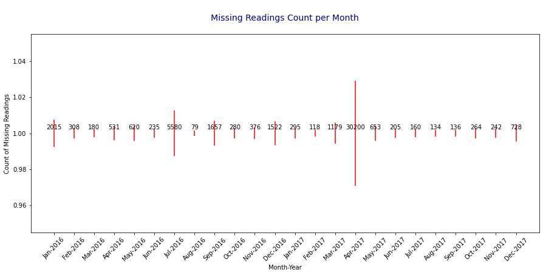

```python
# Convert the list to a DataFrame
missing_df = pd.DataFrame({'Timestamp': missing_values['Timestamp']})

# Extract month and year information
missing_df['MonthYear'] = missing_df['Timestamp'].dt.to_period('M')

# Count the number of timestamps for each month/year
count_per_month_year = missing_df.groupby('MonthYear').size().reset_index(name="Count of Missing Readings")
count_per_month_year['MonthYear'] = count_per_month_year['MonthYear'].dt.strftime('%b-%Y')


# Display the result
plt.figure(figsize=(15, 6))
plt.scatter(count_per_month_year['MonthYear'], [1]*count_per_month_year.shape[0], marker='|', color='red',
            s=count_per_month_year['Count of Missing Readings'])


for index, row in count_per_month_year.iterrows():
    plt.annotate(row['Count of Missing Readings'],
                 xy=(row['MonthYear'], 1),
                 xytext=(0, 5),
                 textcoords='offset points',
                 ha='center',
                 va='bottom')


plt.xlabel('Month-Year')
plt.ylabel('Count of Missing Readings')
plt.title('\nMissing Readings Count per Month\n', size=14, color="navy")
plt.xticks(rotation=45)
plt.show()
```

```python
# Drop rows for April 2017
complete_tt_resampled = complete_tt_resampled[~((complete_tt_resampled['Timestamp'].dt.year == 2017) & (complete_tt_resampled['Timestamp'].dt.month == 4))]

# Reset index if needed
complete_tt_resampled.reset_index(drop=True, inplace=True)

# Display the modified DataFrame
print(complete_tt_resampled)
```

```
                  Timestamp  Power_kw  Setpoint_kw  Wind_ms
0       2016-01-01 00:00:00     904.0        900.0     17.0
1       2016-01-01 00:01:00     899.0        900.0     15.1
2       2016-01-01 00:02:00     911.0        900.0     18.1
3       2016-01-01 00:03:00     900.0        900.0     23.1
4       2016-01-01 00:04:00     903.0        900.0     19.4
...                     ...       ...          ...      ...
1009435 2017-12-31 23:55:00      53.0        900.0      4.9
1009436 2017-12-31 23:56:00      54.0        900.0      5.0
1009437 2017-12-31 23:57:00      67.0        900.0      5.1
1009438 2017-12-31 23:58:00      63.0        900.0      5.6
1009439 2017-12-31 23:59:00      74.0        900.0      5.4

[1009440 rows x 4 columns]
```

```python
def plot_wind_speed_over_time(data, month, year):
    """
    Plot the line plot of Wind_ms for a specified month and year.

    Parameters:
    - data: Pandas DataFrame containing the relevant data.
    - month: Name of the month (e.g., 'July').
    - year: Year (e.g., 2016).

    Returns:
    - fig: Matplotlib Figure object containing the plotted line plot.
    """
    # Filter data for the specified month and year
    filtered_data = data[(data['Timestamp'].dt.month_name() == month) & (data['Timestamp'].dt.year == year)]

    # Plot the line plot
    fig, ax = plt.subplots(figsize=(14, 6))
    sns.lineplot(data=filtered_data, x='Timestamp', y='Wind_ms', color='royalblue', marker='o', ax=ax)
    ax.set_title(f'\nWind Speed Over Time - {month} {year}\n', size=14, color="navy")
    ax.set_xlabel('Timestamp')
    ax.set_ylabel('Wind Speed (ms)')
    ax.tick_params(rotation=45)  # Rotate x-axis labels for better visibility
    ax.grid(True)
    plt.tight_layout()

    return fig
```

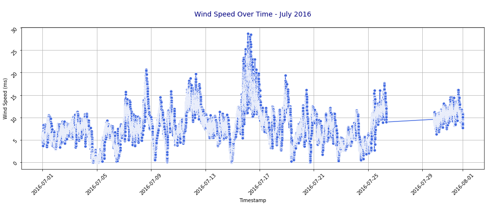

```python
july2016wind=plot_wind_speed_over_time(complete_tt_resampled, 'July', 2016)
```

Let’s analyse another month to see if it follows the same pattern of missing consecutive days as July, this time we will choose January. The plot below shows that again readings are missing for consecutive days. An important question to ask is why there are no readings? Did the turbine break down or did the reader stop working?

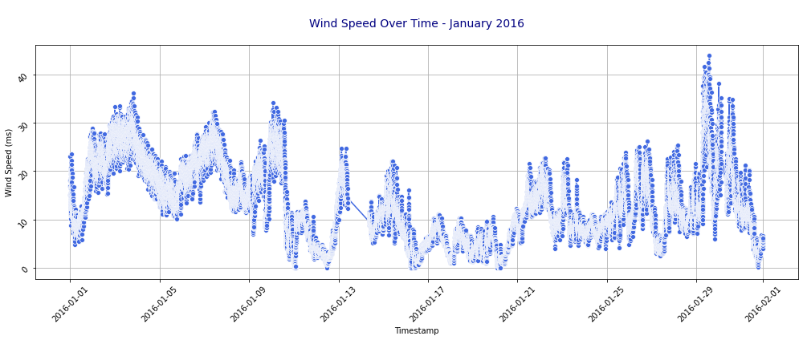

```python
jan2016wind=plot_wind_speed_over_time(complete_tt_resampled, 'January', 2016)
```

Given that this behaviour occurs every month, it would be inaccurate to assume monthly turbine breakdowns or maintenance works are carried out every month. A more plausible explanation is a potential issue with the reader while power supply remains intact. Consequently, we will calculate the average of the specific missing timestamps throughout the month and use it to fill in the readings.

```python
# Create columns for month and hour
complete_tt_resampled['Month'] = complete_tt_resampled['Timestamp'].dt.month
complete_tt_resampled['Hour'] = complete_tt_resampled['Timestamp'].dt.hour
complete_tt_resampled['Year'] = complete_tt_resampled['Timestamp'].dt.year

# Group by month and hour, and calculate the mean
monthly_hourly_means = complete_tt_resampled.groupby(['Year','Month', 'Hour']).mean().reset_index()
monthly_hourly_means
```

|  | Year | Month | Hour | Power_kw | Setpoint_kw | Wind_ms |
| --- | --- | --- | --- | --- | --- | --- |
| 0 | 2016 | 1 | 0 | 536.886750 | 900.000000 | 13.271065 |
| 1 | 2016 | 1 | 1 | 528.427844 | 884.324278 | 13.374194 |
| 2 | 2016 | 1 | 2 | 516.580952 | 869.468908 | 13.732045 |
| 3 | 2016 | 1 | 3 | 543.970115 | 895.114943 | 13.173161 |
| 4 | 2016 | 1 | 4 | 524.819436 | 888.211616 | 12.995630 |
| ... | ... | ... | ... | ... | ... | ... |
| 547 | 2017 | 12 | 19 | 560.196872 | 841.747573 | 12.577454 |
| 548 | 2017 | 12 | 20 | 540.104315 | 841.015838 | 12.330421 |
| 549 | 2017 | 12 | 21 | 523.209140 | 841.712903 | 12.226613 |
| 550 | 2017 | 12 | 22 | 522.014909 | 857.261182 | 12.031640 |
| 551 | 2017 | 12 | 23 | 512.691351 | 869.474279 | 11.497795 |

552 rows × 6 columns

```python
# Merge the big DataFrame with the averages DataFrame to get the mean values
merged_df = pd.merge(complete_tt_resampled, monthly_hourly_means, on=['Year', 'Month', 'Hour'], how='left', suffixes=('', '_mean'))

# Identify missing values in the original columns
missing_mask = merged_df['Power_kw'].isna() | merged_df['Setpoint_kw'].isna() | merged_df['Wind_ms'].isna()

# Replace missing values with the corresponding mean values for the identified rows, excluding April 2017
exclude_april_mask = (merged_df['Month'] == 4) & (merged_df['Year'] == 2017)
merged_df.loc[missing_mask & ~exclude_april_mask, 'Power_kw'] = merged_df.loc[missing_mask & ~exclude_april_mask, 'Power_kw_mean']
merged_df.loc[missing_mask & ~exclude_april_mask, 'Setpoint_kw'] = merged_df.loc[missing_mask & ~exclude_april_mask, 'Setpoint_kw_mean']
merged_df.loc[missing_mask & ~exclude_april_mask, 'Wind_ms'] = merged_df.loc[missing_mask & ~exclude_april_mask, 'Wind_ms_mean']

# Drop the unnecessary columns
merged_df = merged_df.drop(['Power_kw_mean', 'Setpoint_kw_mean', 'Wind_ms_mean', 'Month', 'Hour', 'Year'], axis=1)

# Display the result
# print(merged_df)
```

```python
#Updating the data set with the filled data set
complete_tt_resampled =merged_df.copy()
```

We have succesfully filled in all missing values.

```python
# Check for missing values in the merged_df DataFrame
missing_values = complete_tt_resampled.isnull().sum()

# Display the count of missing values for each column
print(missing_values)
```

```
Timestamp      0
Power_kw       0
Setpoint_kw    0
Wind_ms        0
dtype: int64
```

*Setpoint Efficacy*

To conclude our assessment of data accuracy, we must examine the alignment between the setpoint and the actual power generated. Ideally, when a turbine is subjected to forced curtailment by the network operator, the power generated should consistently remain below or at the setpoint. However, we hypothesize that there may be instances where the generated power slightly exceeds the setpoint due to potential operational factors or system dynamics that fail to foresee and curtail the power before it is generated. We allow for a 10% in excess of the setpoint.

```python
# identify instances where power exceeded the setpoint

setpoint_grace_factor = 0.1
power_exceeds_setpoint_df = complete_tt_resampled[complete_tt_resampled['Power_kw'] >
                                                  (1+setpoint_grace_factor) * complete_tt_resampled['Setpoint_kw']]

print(f"\nThere are {power_exceeds_setpoint_df.shape[0]} instances where power exceeded 110% of the setpoint value, \
representing {round(power_exceeds_setpoint_df.shape[0]/complete_tt_resampled.shape[0]*100,3)}% of all records.\n")
```

```
There are 24627 instances where power exceeded 110% of the setpoint value, representing 2.44% of all records.
```

```python
# Cap Power at setpoint
complete_tt_resampled['Power_kw'] = np.min([complete_tt_resampled['Setpoint_kw'],
                                            complete_tt_resampled['Power_kw']], axis=0)
```

We cap the values for power at the setpoint.

```python
#Saving the cleaned data set in a csv file
complete_tt_resampled.to_csv('complete_tt_resampled.csv', index=False)
```

## Appendix 2: Residential Demand Data Pre-processing

The data includes a timestamp at a second granularity, the average demand during the time interval (measured in kilowatts), and the number of households included in the statistics of the measurement time interval.

```python
residential_demand.head(10)
```

|  | Timestamp | Demand_mean_kw | N_households |
| --- | --- | --- | --- |
| 0 | 2017-01-01 00:00:00 | 0.220106 | 5428 |
| 1 | 2017-01-01 00:30:00 | 0.205945 | 5429 |
| 2 | 2017-01-01 01:00:00 | 0.189090 | 5429 |
| 3 | 2017-01-01 01:30:00 | 0.173118 | 5429 |
| 4 | 2017-01-01 02:00:00 | 0.159051 | 5429 |
| 5 | 2017-01-01 02:30:00 | 0.147656 | 5429 |
| 6 | 2017-01-01 03:00:00 | 0.136673 | 5429 |
| 7 | 2017-01-01 03:30:00 | 0.130484 | 5429 |
| 8 | 2017-01-01 04:00:00 | 0.124209 | 5429 |
| 9 | 2017-01-01 04:30:00 | 0.120191 | 5429 |

Upon initial observation, it appears that the readings are captured at the end of 30-minute intervals. However, similar to the telemetry dataset, this hypothesis will require validation.

*Inspect Data Types*

```python
residential_demand.dtypes #all columns are the right data types
```

```
Timestamp         datetime64[ns]
Demand_mean_kw           float64
N_households               int64
dtype: object
```

*Summary Statistics of Data*

```python
summary_statistics=residential_demand.describe().round(3)
summary_statistics
```

|  | Demand_mean_kw | N_households |
| --- | --- | --- |
| count | 17568.000 | 17568.000 |
| mean | 0.219 | 8630.642 |
| std | 0.090 | 2999.142 |
| min | 0.087 | 5406.000 |
| 25% | 0.144 | 6781.000 |
| 50% | 0.212 | 8190.500 |
| 75% | 0.274 | 9652.000 |
| max | 0.510 | 30037.000 |

*Check for Missing Values in existing entries*

```python
# Count missing entries per column
missing_count = residential_demand.isnull().sum()

# Display count of missing entries per column
print("Missing Entries per Column:")
print(missing_count)
```

```
Missing Entries per Column:
Timestamp         0
Demand_mean_kw    0
N_households      0
dtype: int64
```

There are no missing values.

*Check Time Interval Hypothesis and identify missing readings*

```python
residential_demand['Timestamp'].diff().describe()
```

```
count              17567
mean     0 days 00:30:00
std      0 days 00:00:00
min      0 days 00:30:00
25%      0 days 00:30:00
50%      0 days 00:30:00
75%      0 days 00:30:00
max      0 days 00:30:00
Name: Timestamp, dtype: object
```

It is confirmed that the time interval between measurements is 30 minutes.

*Examine Number of Households Evolution over Time and Treat Outliers*

```python
def plot_households_over_time(data):
    """
    Plot the line plot of N_households over time.

    Parameters:
    - data: Pandas DataFrame containing the relevant data.

    Returns:
    - fig: Matplotlib Figure object containing the plotted line plot.
    """
    fig, ax = plt.subplots(figsize=(14, 6))
    sns.lineplot(data=data, x='Timestamp', y='N_households', color='royalblue', marker='o', ax=ax)
    ax.set_title('\nN Households Over Time\n', size=14, color="navy")
    ax.set_xlabel('Timestamp')
    ax.set_ylabel('N Households')
    ax.grid(True)
    plt.tight_layout()

    return fig
```

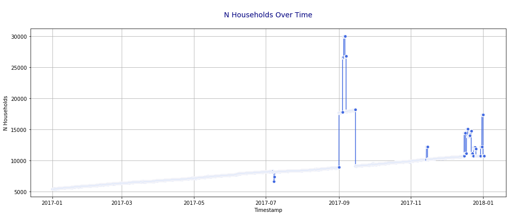

```python
plot_households=plot_households_over_time(residential_demand)
```

The irregular spikes and dips observed in the number of households during July 2017, September 2017, November 2017, December 2017, and January 2018 are deemed data anomalies since there is no discernible rationale for such abrupt fluctuations in the aggregated statistics, specially knowing that the number of households in Orkney Islands during 2011 was 9,725 households according to the published 2011 Scotland Census data. Consequently, these anomalous entries will be substituted with values that align with the gradual upward trend apparent in the dataset. To identify this trend and the reasonable ranges for the movement from one point to the next, further analysis will be conducted.

It is important to take a step back here and recognize that the observed increasing trend in household numbers does not accurately reflect the total population of the Orkney Islands. According to the published 2011 Scotland Census data, the number of households in 2011 was reported as 9,725. Therefore, it is highly improbable that by 2017, the number of households would have dropped to 5,000 and then subsequently increased every 30 minutes to reach the 10,000 household mark by 2018. This discrepancy suggests that the data represents a growing sample of households included in the data collection and processing over the course of the year. It is plausible that smart meters were gradually installed in households during this period, allowing for the gradual capture of household data.

```python
residential_demand['Household_Movement'] = residential_demand['N_households'].diff()

residential_demand['Household_Movement'].describe()
```

```
count    17567.000000
mean         0.301873
std        165.390389
min      -9069.000000
25%          0.000000
50%          0.000000
75%          1.000000
max       8795.000000
Name: Household_Movement, dtype: float64
```

```python
# Step 1: Identify thresholds for spikes and troughs
threshold = 100

# Step 2: Replace anomalies with values following linear trend
smooth_data = residential_demand['N_households'].copy()  # Create a copy of the original data to work with

for index in range(1,len(smooth_data)):
    # Identify if movement in number of households exceeds the threshold
    if np.abs((smooth_data.iloc[index] - smooth_data.iloc[index-1]))>threshold:

        # Select smoothed readings prior to the anomaly index
        indices = list(range(0,index-1))
        y = smooth_data.iloc[indices]

        # Fit linear model
        linear_model = np.polyfit(indices, y, 1)

        # Predict values along the linear trend
        x_pred = [index]
        y_pred = np.polyval(linear_model, x_pred)

        # Replace anomaly with predicted values
        smooth_data.loc[index] = y_pred[0]


# Update 'N_households' column with smoothed data
residential_demand['N_households'] = smooth_data
```

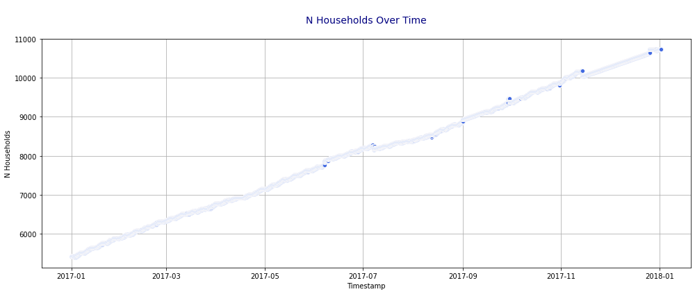

```python
smoothed_households=plot_households_over_time(residential_demand)
```

*Examine Mean Demand Evolution over Time*

```python
# Extract month and year from 'Timestamp' column and combine them
residential_demand['Month_Year'] = residential_demand['Timestamp'].dt.strftime('%b-%Y')

# Set the order of months for plotting
month_order = residential_demand['Month_Year'].unique()
```

```python
def plot_mean_demand_over_time(data, x_column, y_column, order=None):
    """
    Create a box plot per month

    Parameters:
    - data: Pandas DataFrame containing the relevant data.
    - x_column: Column representing the x-axis (e.g., 'Month_Year').
    - y_column: Column representing the y-axis (e.g., 'Demand_mean_kw').
    - order: Order of x-axis categories (optional).

    Returns:
    - fig: Matplotlib Figure object containing the plotted box plot.
    """
    fig, ax = plt.subplots(figsize=(10, 6))
    sns.boxplot(data=data, x=x_column, y=y_column, order=order, color='skyblue', ax=ax)
    ax.set_title('\nDistribution of Mean Household Demand Over Time\n', size=15, color="navy")
    ax.set_xlabel('Month-Year')
    ax.set_ylabel('Demand (KW)')
    ax.tick_params(rotation=45)
    plt.tight_layout()

    return fig
```

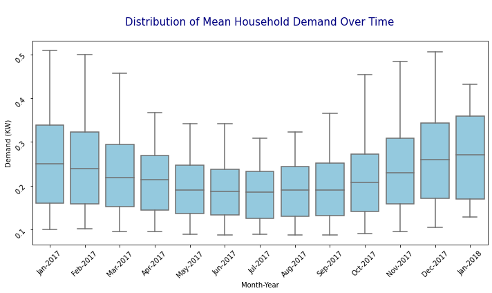

```python
demand_histogram= plot_mean_demand_over_time(residential_demand,'Month_Year','Demand_mean_kw' )
```

Examining the distribution of demand over the course of a year reveals a monthly seasonality. This pattern suggests that, on average, demand peaks during the winter months and declines to its lowest levels during the summer months. This observed seasonality aligns with expectations for a region like the UK, where there is typically heightened demand for electricity during colder periods for heating and lighting purposes. While during the summer months, the demand for electricity typically diminishes as temperatures do not necessitate extensive use of air conditioning or other cooling systems.

The boxplots further reinforce the reliability of the data, where there are no suspicious outliers or extreme values within the dataset that would raise concerns regarding data accuracy or integrity. This absence of significant anomalies provides confidence in the validity of the observed demand patterns and trends.

```python
#Saving the cleaned residential demand data into a csv
# residential_demand.to_csv('residential_demand_cleaned.csv', index=False)
```

## Appendix 3: Financial Model

In this section, we construct our financial model, which encapsulates our strategy formulated based on research, historical data analysis, and key drivers for driving user adoption of our proposed program. We will start by setting all the assumptions then create a resuable function that utilises all the assumptions to generate the financial metrics over the months; revenues, costs and profits.

Our primary objective is to encourage new users to adopt the curtailed energy program by purchasing and installing Kaluza's DR device in their households. This smart device facilitates charging heaters using energy from off-peak periods, which would otherwise have been curtailed, thereby generating additional revenue for wind farmers. In addition to revenue from device sales, Kaluza also earns a fee on the energy sold during these periods.

A major driver of user adoption is marketing expenditure. Our marketing campaigns aim to raise community awareness about the environmental benefits of transitioning to renewable energy sources and the potential cost savings for households. We divide our marketing strategy into three phases:

- Strong Marketing: Initially, we focus on creating strong awareness while offering aggressive discounts on the devices.
- Run-off: During this phase, we reduce marketing expenditure but maintain engagement with our target audience.
- Remaining Months: In the final phase, we leverage network effects and word-of-mouth to sustain momentum and drive further adoption.

```python
# Initiate the assumptions dictionary
assumptions = {}

# Number of months we will consider in the analysis
horizon = 36

# Creating months list
months = [i for i in range(1,horizon + 1)]
```

**Marketing Assumptions**

```python
# Define strong marketing period
strong_budget = 300000
strong_months = 6
strong_budget_months = [strong_budget/strong_months for i in range(strong_months)]

# Define run-off makerting period
run_off_budget = 90000
# Months in the run off phase
run_off_months = 18
run_off_budget_months = [run_off_budget/run_off_months for i in range(run_off_months)]

# Define remaining months period
remaining_budget = 0
remaining_months = max(months) - strong_months - run_off_months
remaining_months_budget_months = [remaining_budget/remaining_months for i in range(remaining_months)]

# Final marketing expenditure
marketing_expenditure = strong_budget_months + run_off_budget_months + remaining_months_budget_months
```

**Penetration Pattern Assumptions**

After defining a marketing budget and strategy, we start enumerating the assumptions that will control the penetration these initiatives will have on the population of Orkney. The assumption here is that the penetration reaches a peak after a few months of campaigning, stabilizes after that and finally dies off. So we will set a penetration pattern first, which will control the general behaviour of all of the penetration rates. Then, we derive specific penetration rates per segment.

The segments are defined based on the type of energy currently used for heating in the households. The electric and non-electric consumption are not possible to dissociate in practice, but we treat them as separate segments here in order to calculate carbon impacts and have more clarity in the model. After deriving this penetration rates and with the number of households and distribution of consumption we can get the model for the number of adopters per segment and in total

```python
# Set the number of months to reach desired penetration rate assumption
assumptions['n_months_to_target_pr'] = 24

# Set the assumption for the number of households
assumptions['n_households'] = num_households

# Set the heating energy distribution assumptions
assumptions['electric_non_renewable_dist'] = .31
assumptions['electric_renewable_dist'] =.1
assumptions['oil_dist'] =.36

# Define penetration rates and periods
penetration_rate_1 = 0.5
len_rate_1 = 3
penetration_rate_2 = 1.5
len_rate_2 = 4
penetration_rate_3 = 1
len_rate_3 = 17
penetration_rate_4 = 0
len_rate_4 = max(months) - len_rate_1 - len_rate_2 - len_rate_3

# Penetration rate development
penetration_rate_pattern =  [penetration_rate_1 for i in range(len_rate_1)] + \
                            [penetration_rate_2 for i in range(len_rate_2)] + \
                            [penetration_rate_3 for i in range(len_rate_3)] + \
                            [penetration_rate_4 for i in range(len_rate_4)]

# Set first rate to zero (no adoption in initial month)
penetration_rate_pattern[0] = 0




# Set the penetration rates assumptions
assumptions['electric_non_renewable_n_households'] = round(assumptions['electric_non_renewable_dist']*assumptions['n_households'],0)
assumptions['electric_renewable_n_households'] = round(assumptions['electric_renewable_dist']*assumptions['n_households'],0)
assumptions['oil_n_households'] =  round(assumptions['oil_dist']*assumptions['n_households'],0)
```

We then define all the other underlying assumptions, ranging from energy prices, CO2 emissions ranges and costs, kaluza fees to be acquired from the wind farmers, etc.

**Energy Assumptions**

```python
# Set electricity consumption assumption in kWh
assumptions['elec_cons_kwh'] = 628

# Percentage of people who will increase their consumption due to lower monthly costs
assumptions['change_cons'] = 0.65

# Set electricity price assumptions
assumptions['elec_price_non_renewable'] = 0.1757894737
assumptions['elec_price_renewable'] = 0.1757894737
assumptions['elec_price_oil'] = 0.05981666667

# Set wind generated price assumptions
assumptions['wind_price_non_renewable'] = 0.1525949123
assumptions['wind_price_renewable'] = 0.1525949123
assumptions['wind_price_oil'] = 0.06640898246

# Set CO2 costs assumptions. This drives the government's subsidy
assumptions['co2_cost_non_renewable'] = 0.00108
assumptions['co2_cost_renewable'] = 0
assumptions['co2_cost_oil'] = 0.00145

# Retail price of wind generated energy that would be curtailed
assumptions['curtailed_wind_price'] = 0.12
```

**Kaluza's Fee from Wind farmers**

```python
# Kaluza's fee to the excess revenue created from the program
assumptions['kaluza_top_fee'] = .75
assumptions['kaluza_med_fee'] = .5
assumptions['kaluza_bottom_fee'] = .2
```

**Devices Requirements and Costs**

```python
# Set the number of dr devices per household
assumptions['n_dr_devices_per_household'] = 4
assumptions['dr_upfront_investment'] = 190
assumptions['installation_cost'] = 90

# Set the number of quantum storage devices per household
assumptions['n_quantum_storage_devices_per_household'] = 3

# Set the number of quantum cylinders per household
assumptions['n_quantum_cylinder_devices_per_household'] = 1

# Quantum boiler equipment upfront costs
assumptions['quantum_boiler_upfront_costs'] = 1199.8425
assumptions['quantum_storage_upfront_costs'] = 2067.525
```

**Kaluza Discounts and Subsidies to Households**

```python
# DR Devices
discount_rate_1 = [1, 1, .75, .5, .25, 0]
first_hh_joined = [0, 100, 350, 850, 1850, 10000000]


# Kaluza's heaters/boilers
discount_rate_quantum = [.75, .75, .5, .25, 0]
first_hh_joined_quantum = [0, 25, 75, 175, 3865]


# Function to get the proper index of the rate
def find_last_index_smaller(first_hh_joined, value_to_find):
    for i in range(len(first_hh_joined)):
        if first_hh_joined[i] >= value_to_find:
            if i > 0:
                last_index_smaller = i - 1
            else:
                last_index_smaller = -1
            break
    else:
        last_index_smaller = len(first_hh_joined) - 1

    return last_index_smaller
```

**Operational costs and Costs of Goods Sold Assumptions**

```python
# Bonus per unit sold
assumptions['bonus_per_unit'] = 15

# Hardware COGS
assumptions['harware_sale_price'] = 100
assumptions['cost_%'] = .1


# Kaluza's cost tier by number of devices in operation
operating_costs_n_devices = [22000, 45000, 112000, 224000]
discount_rate_n_devices = [0, 1000, 5000, 10000]
```

**Financial Business Case Function**

```python
def business_case(nren_pr, ren_pr, oil_pr):

    """
    Calculate number of adopters
    """

    # Set the penetration rates assumptions
    assumptions['electric_non_renewable_pr'] = nren_pr
    assumptions['electric_renewable_pr'] = ren_pr
    assumptions['oil_pr'] =  oil_pr

    # Initiate monthly rates
    monthly_rate_nr = []
    monthly_rate_r = []
    monthly_rate_oil = []

    def get_rates(penetration_rate, monthly_rate):
        monthly_rate = [0]
        for month in months[1:]:
            if (month <= assumptions['n_months_to_target_pr']) & (sum(monthly_rate) < penetration_rate):
                month_rate = penetration_rate/assumptions['n_months_to_target_pr']*penetration_rate_pattern[month-1]
            else:
                month_rate = 0
            monthly_rate.append(month_rate)
        return monthly_rate

    # get final penetration rates
    monthly_rate_nr = get_rates(assumptions['electric_non_renewable_pr'], monthly_rate_nr)
    monthly_rate_r = get_rates(assumptions['electric_renewable_pr'], monthly_rate_r)
    monthly_rate_oil = get_rates(assumptions['oil_pr'], monthly_rate_r)

    # Get Number of new adopters by segment
    electric_renewable_adopters = np.array(assumptions['electric_renewable_n_households'])*monthly_rate_r
    electric_non_renewable_adopters = np.array(assumptions['electric_non_renewable_n_households'])*monthly_rate_nr
    oil_adopters = np.array(assumptions['oil_n_households'])*monthly_rate_oil

    # Get total new adopters
    total_adopters = list(electric_non_renewable_adopters + electric_renewable_adopters + oil_adopters)



    #___________________________________________________________________________________________________________________________




    """
    Calculate consumption; before and after DR adoption
    With the number of adopters per month per segment, we can get the consumption of electricity by these adopters.
    To do this, we need information about consumption and energy prices, which we take from the research section.
    There are two important drivers here. One of them is the percentage of people who will increase consumption due to
    the decrease in costs. The increase in consumption is estimated to be proportional to the difference in the prices of
    regular electricity and the curtailed price. Curtailed here refers to the energy that the Smart device will use to charge
    the heaters, which would otherwise have been curtailed to balance the load.
    """

   # Expected changes in consumption
    exp_change_cons_renewable = max((assumptions['elec_price_renewable']-assumptions['wind_price_renewable'] -
                                        (assumptions['co2_cost_renewable'] - assumptions['co2_cost_renewable']))*
                                        (assumptions['elec_cons_kwh']/assumptions['wind_price_renewable'])*assumptions['change_cons'],0)

    exp_change_cons_non_renewable = max((assumptions['elec_price_non_renewable']-assumptions['wind_price_non_renewable'] -
                                    (assumptions['co2_cost_renewable'] - assumptions['co2_cost_non_renewable']))*
                                    (assumptions['elec_cons_kwh']/assumptions['wind_price_non_renewable'])*assumptions['change_cons'],0)

    exp_change_cons_oil = max((assumptions['elec_price_oil']-assumptions['wind_price_oil'] -
                          (assumptions['co2_cost_renewable'] - assumptions['co2_cost_oil']))*
                        (assumptions['elec_cons_kwh']/assumptions['wind_price_oil'])*assumptions['change_cons'],0)

    # New consumption per segment
    new_cons_renewable = assumptions['elec_cons_kwh'] + exp_change_cons_renewable
    new_cons_non_renewable = assumptions['elec_cons_kwh'] + exp_change_cons_renewable
    new_cons_oil = assumptions['elec_cons_kwh'] + exp_change_cons_oil

    # New costs per segment
    new_cost_renewable = new_cons_renewable*(assumptions['wind_price_renewable'] - (assumptions['co2_cost_renewable'] - assumptions['co2_cost_renewable']))
    new_cost_non_renewable = new_cons_non_renewable*(assumptions['wind_price_non_renewable'] - (assumptions['co2_cost_non_renewable'] - assumptions['co2_cost_renewable']))
    new_cost_oil = new_cons_oil*(assumptions['wind_price_oil'] - (assumptions['co2_cost_oil'] - assumptions['co2_cost_renewable']))



    # Expected change in energy consumption per household
    consumption_change_per_month = list(np.nan_to_num((exp_change_cons_renewable*np.cumsum(electric_renewable_adopters) +
                                        exp_change_cons_non_renewable*np.cumsum(electric_non_renewable_adopters) +
                                        exp_change_cons_oil*np.cumsum(oil_adopters))/np.cumsum(total_adopters),nan=0))

    # Get the total new consumption per month
    total_consumption_per_month = [x + assumptions['elec_cons_kwh'] for x in consumption_change_per_month]

    # First value to zero as there is no consumption in the initial month
    total_consumption_per_month[0] = 0


    # Expected current energy prices
    expected_current_energy_prices = list(np.nan_to_num((assumptions['elec_price_renewable']*np.cumsum(electric_renewable_adopters) +
                                        assumptions['elec_price_non_renewable'] *np.cumsum(electric_non_renewable_adopters) +
                                        assumptions['elec_price_oil']*np.cumsum(oil_adopters))/np.cumsum(total_adopters),nan=0))

    current_energy_costs_per_household = list(np.array(expected_current_energy_prices)*assumptions['elec_cons_kwh'])

    new_energy_costs_per_household = list(np.nan_to_num((new_cost_renewable*np.cumsum(electric_renewable_adopters) +
                                        new_cost_non_renewable*np.cumsum(electric_non_renewable_adopters) +
                                        new_cost_oil*np.cumsum(oil_adopters))/np.cumsum(total_adopters),nan=0))


    #___________________________________________________________________________________________________________________________
```

```python
    """
    Calculate revenue
    With the new estimated consumption, we are able to estimate the total revenue that wind farmers will make from the program.
    On this revenue, Kaluza will charge a fee to compensate the implementation of the system that allows the curtailed energy to be
    used.*/

    """
    # Total new wind energy sold through the program
    wind_energy_sold = np.array(exp_change_cons_renewable)*np.cumsum(electric_renewable_adopters) + \
                       np.array(new_cons_non_renewable)*np.cumsum(electric_non_renewable_adopters)+\
                       np.array(new_cons_oil)*np.cumsum(oil_adopters)


    # Total revenue from sold wind energy
    wind_energy_revenue = assumptions['wind_price_renewable']*np.array(exp_change_cons_renewable)*np.cumsum(electric_renewable_adopters) + \
                          assumptions['wind_price_non_renewable']*np.array(new_cons_non_renewable)*np.cumsum(electric_non_renewable_adopters)+\
                          assumptions['wind_price_oil']*np.array(new_cons_oil)*np.cumsum(oil_adopters)



    # Kaluza's fee per month
    kaluza_fee = [assumptions['kaluza_top_fee'] if x <= strong_months
                  else assumptions['kaluza_med_fee'] if x<= assumptions['n_months_to_target_pr']
                  else assumptions['kaluza_bottom_fee'] for x in months]

    # Kaluza's revenue per month
    kaluza_wind_revenue = list(np.array(kaluza_fee) * np.array(wind_energy_revenue))


    # Kaluza's revenue per month
    wind_farmer_revenue = wind_energy_revenue -  kaluza_wind_revenue


    #___________________________________________________________________________________________________________________________

    """
    Next, we calculate the cost profile of this implementation.
    """

    """
    Calculate DR Device subsidy cost
    Under the assumption that Kaluza will subsidize some of the equipment costs and installations,
    these need to be considered in order to get the net revenue from this project.
    We start by estimating the installation costs of the DR implementation.
    The rationale used here is based on the total base of adopters,
    and that we will provide discounts rates for the n first adopters.
    These variables are set in the lists discount_rate_1 and first_hh_joined.
    """


    # Get the total number of dr devices sold per month
    total_dr_devices_per_month = list(assumptions['n_dr_devices_per_household'] * np.array(total_adopters))

    # Get the total number of quantum heaters devices sold per month --> Oil adopters times the total devices needed per hh
    total_quantum_devices_per_month = list((assumptions['n_quantum_storage_devices_per_household'] +
                                           assumptions['n_quantum_cylinder_devices_per_household']) * np.array(oil_adopters))

    # Implementation costs for a single household
    implementation_costs = assumptions['n_dr_devices_per_household']*assumptions['dr_upfront_investment']
    quantum_costs = assumptions['quantum_boiler_upfront_costs'] + assumptions['quantum_storage_upfront_costs']
    installation_costs = assumptions['n_dr_devices_per_household']*assumptions['installation_cost']

    # Total DR costs
    total_dr_costs = list(implementation_costs * np.array(total_adopters))

    # Total DR installation costs
    total_dr_installation = list(installation_costs * np.array(total_adopters))

    # Total Quantum costs
    total_quantum_costs = list(quantum_costs * np.array(oil_adopters))


    kaluza_dr_cost_total = []
    kaluza_dr_installation_costs = []
    dr_discount = 0

    for i,base in enumerate(np.cumsum(total_adopters)):
        last_index_smaller = find_last_index_smaller(first_hh_joined, base)
        dr_discount = (discount_rate_1[last_index_smaller] + discount_rate_1[last_index_smaller+1])/2
        kaluza_dr_cost_total.append(dr_discount*total_dr_costs[i])
        kaluza_dr_installation_costs.append(dr_discount*total_dr_installation[i]*(1-dr_discount))

    #___________________________________________________________________________________________________________________________


    """
    Calculate Heaters/Boilers Subsidy Cost
    Next, we repeat a similar process for the Quantum devices that Kaluza will subsidize.
    Again, the size of the subsidy is a function of the the total base.
    """

    kaluza_quantum_cost_total = []
    quantum_discount = 0

    for i,base in enumerate(np.cumsum(oil_adopters)):
        last_index_smaller = find_last_index_smaller(first_hh_joined_quantum, base)
        quantum_discount = (discount_rate_quantum[last_index_smaller] + discount_rate_quantum[last_index_smaller+1])/2
        kaluza_quantum_cost_total.append(quantum_discount*total_quantum_costs[i])


    #___________________________________________________________________________________________________________________________


    """
    Calculate Net Revenue (Gross Margin)
    The last step to calculate the net revenue is to estimate the supply costs of the DR devices.
    On top of this, we include the subsidies made to the quantum devices, dr devices and installation costs.
    Lastly, we provision bonuses for the sales staff for the successful conversion of leads into constumers.
    """
    # Total revenue
    total_revenue = np.array(kaluza_wind_revenue) + np.array(total_dr_costs)

    # COGS per DR device (assuming a 10% cost of production)
    assumptions['hardware_cogs'] = assumptions['harware_sale_price']*assumptions['cost_%']

    # Total hardware COGS
    total_hardware_cogs = assumptions['hardware_cogs'] * np.array(total_adopters) * assumptions['n_dr_devices_per_household']

    # Total bonuses
    total_bonuses = assumptions['bonus_per_unit'] * assumptions['n_dr_devices_per_household'] * np.array(total_adopters)

    # Total COGS
    total_cogs = np.array(kaluza_dr_cost_total) + \
                 np.array(kaluza_quantum_cost_total) + \
                 np.array(kaluza_dr_installation_costs) + \
                 np.array(total_bonuses) + \
                 np.array(total_hardware_cogs)
```

```python
    net_revenue = total_revenue - total_cogs


    #___________________________________________________________________________________________________________________________


    """
    Calculate Operating Profit
    Finally we add the operational costs of operating this infrastructure in order to estimate the operating profit of
    the project
    """

    drs_operating_costs = []
    costs = 0

    for i,n_devices in enumerate(np.cumsum(total_dr_devices_per_month)):
        last_index_smaller = find_last_index_smaller(discount_rate_n_devices, n_devices)
        operating_costs = operating_costs_n_devices[last_index_smaller]
        drs_operating_costs.append(operating_costs/12)

    # Fixing the first value
    drs_operating_costs[0] = operating_costs_n_devices[0]/12

    operating_profit = net_revenue - np.array(drs_operating_costs) - np.array(marketing_expenditure)



    return total_revenue, total_cogs, net_revenue, operating_profit, total_adopters, wind_farmer_revenue, wind_energy_sold
```

Finally, we define functions to run the business case, store and display the results.

```python
def results(nren_pr, ren_pr, oil_pr):

    results = business_case(nren_pr, ren_pr, oil_pr)

    pen_ratios = [ nren_pr, ren_pr, oil_pr]

    results_dict = {
        "total_revenue": results[0],
        "total_cogs": results[1],
        "net_revenue": results[2],
        "operating_profit": results[3],
        "total_adopters": results[4],
        "wind_farmer_revenue": results[5],
        "curtailed_wind_sold": results[6]

    }

    cumulative_operating_profit =  np.cumsum(results_dict['operating_profit'])
    break_even_month = next(i for i, val in enumerate(cumulative_operating_profit) if val >= 0)+1

    num_adopters = sum(results[4])

    return results_dict, break_even_month, num_adopters, pen_ratios





def display_bc_results(results, breakeven_month, num_adopters, pen_ratios):

    # Convert amounts to millions of pounds
    revenue_millions = [amount / 1e6 for amount in results['total_revenue']]
    operating_profit_millions = [amount / 1e6 for amount in results['operating_profit']]
    cum_operating_profit_millions = [amount / 1e6 for amount in np.cumsum(results['operating_profit'])]

    total_pr = num_adopters / num_households

    # Months Sequence
    months = range(1, len(revenue_millions) + 1)

    fig, ax1 = plt.subplots(figsize=(20, 8))

    # Plot revenue as a bar plot
    ax1.bar(months, revenue_millions, label='Revenue', color='lightblue')

    # Plot operating profit as a portion of the revenue bar
    for i, op in enumerate(operating_profit_millions):
        if i ==  np.max(months) - 1:
            l = "Operating Profit"
        elif i == 0:
            l = "Operating Loss"
        else:
            l = ""

        if op >= 0:
            ax1.bar(months[i], op, bottom=revenue_millions[i], color='green', alpha=0.5, label = l)
        else:
            ax1.bar(months[i], op, bottom=revenue_millions[i], color='red', alpha=0.3, label =  l)

    # Label the primary y-axis
    ax1.set_xlabel('Project Month')
    ax1.set_ylabel('Financial Metrics (Millions of £)')

    # Format y-axis
    ax1.yaxis.set_major_formatter(ticker.FuncFormatter(lambda x, _: f'{x:,.2f}'))


    # Plot cumulative operating profit as a line plot on secondary y-axis
    ax2 = ax1.twinx()
    ax2.plot(months, cum_operating_profit_millions, label='Cumulative Operating Profit', color='coral')
    ax2.set_ylabel('Cumulative Operating Profit (Millions of £)')
    ax2.yaxis.set_major_formatter(ticker.FuncFormatter(lambda x, _: f'{x:,.2f}'))

    # Draw vertical dashed line at the break-even month
    ax1.axvline(x=breakeven_month - 0.5, color='black', linestyle='--')

    # Annotate the break-even month
    ax1.text(breakeven_month , np.max(revenue_millions)*1.5, f'Break Even Month: {breakeven_month}',
             color='black', size=14, fontweight = 400)

    # Title and subtitle
    plt.title(f'\nFinancial Evaluation - Total Penetration Ratio: {total_pr * 100:,.0f}%\n\n', color = "navy", size = 18)
    subtitle = f'\nNon-Renewable-Electricity-reliant: {pen_ratios[0] * 100:,.0f}%, Renewable-reliant: {pen_ratios[1] * 100:,.0f}%, Oil-reliant: {pen_ratios[2] * 100:,.0f}%'
    plt.suptitle(subtitle, y=0.96, fontsize=14, fontstyle = "italic")

    # x ticks
    plt.xticks(months)


    # Legends
    handles, labels = ax1.get_legend_handles_labels()
    ax1.legend(handles, labels,loc = "upper left", fontsize=12)

    handles, labels = ax2.get_legend_handles_labels()
    ax2.legend(handles, labels, loc = 'center right', fontsize=12)


    plt.show()
```